# Classifying How Well Subjects Use A Dumbbell

Marek Kluczynski

31 January 2016

## Introduction

This paper is part of a course project for the Machine Learning module of the Data Science Specialisation delivered by the Johns Hopkins university on Coursera.

One thing that people regularly do is quantify how much of a particular activity they do, but they rarely quantify how well they do it. Devices such as Jawbone Up, Nike Fuel Band, and Fitbit can collect data about personal activity. A group of enthusiasts collected data using accelerometers on the belt, forearm, arm, and dumbbell from 6 participants.

The data collected can be viewed at http://groupware.les.inf.puc-rio.br/har (see the section on the Weight Lifting Exercise Dataset).

This paper uses machine learning methods to predict the manner in which participants did the exercise; it describes how hte model was built, how cross vaildiation was used, what the expected out of sample error is and why design decisions were made. In addition predictions are made on 20 test cases.

## Packages

The following R packages available on CRAN are used in this paper

```r
require(caret);
require(ggplot2);
require(plyr);
require(dplyr);
require(lubridate);
require(doParallel);
require(AppliedPredictiveModeling);
```

## Data Preparation

The following code downloads the test and training datasets from the URLs provided by Coursera:

```r
#Set File Variables
URL.Training <- 'https://d396qusza40orc.cloudfront.net/predmachlearn/pml-training.csv'
URL.Test <- 'https://d396qusza40orc.cloudfront.net/predmachlearn/pml-testing.csv'
File.Training <- './data/pml-training.csv'
File.Test <- './data/pml-testing.csv'

#Check if data directory exists
if(!dir.exists("./data"))
{
        dir.create("data", showWarnings = TRUE, recursive = FALSE, mode = "0777")
}

# Download Test and Training Datasets
download.file(URL.Training, File.Training)
download.file(URL.Test, File.Test)

#Read files into data frames
TrainingData <- read.csv(file=File.Training, header=TRUE, sep=",",na.strings = "NA"  )
TestData <- read.csv(file=File.Test, header=TRUE, sep=",",na.strings = "NA"  )
```

The original datasets that the assignment dataset was derived from can be found at http://groupware.les.inf.puc-rio.br/har (see the section on the Weight Lifting Exercise Dataset).

The assignment brief provided was to use data from accelerometers on the belt, forearm, arm, and dumbbell. As such the following code selects only data which is from accelerometers as opposed to any other sensor.

```r
#Subset data frames for accelerometers plus classe
names <- c(grep("accel", colnames(TrainingData), value = TRUE), "classe")
names.testdata <- c(grep("accel", colnames(TrainingData), value = TRUE))

#Create subset with only requried columns
TrainingData.filtered <- TrainingData[,names]
TestData.filtered <- TestData[,names.testdata]
```

Next a check for columns which a large number of NAs was completed as invalid values may affect the output of the machine learning algorithm. The following code checks for NA’s and outputs a summary table:

```r
#Check for NA's
TrainingData.NA <- sapply(TrainingData.filtered, function(y) sum(length(which(is.na(y)))))
TrainingData.NA
```

```
##     total_accel_belt var_total_accel_belt         accel_belt_x
##                    0                19216                    0
##         accel_belt_y         accel_belt_z      total_accel_arm
##                    0                    0                    0
##        var_accel_arm          accel_arm_x          accel_arm_y
##                19216                    0                    0
##          accel_arm_z total_accel_dumbbell   var_accel_dumbbell
##                    0                    0                19216
##     accel_dumbbell_x     accel_dumbbell_y     accel_dumbbell_z
##                    0                    0                    0
##  total_accel_forearm    var_accel_forearm      accel_forearm_x
##                    0                19216                    0
##      accel_forearm_y      accel_forearm_z               classe
##                    0                    0                    0
```

```r
#show number of rows
nrow(TrainingData.filtered)
```

```
## [1] 19622
```

The output shows the columns with the string “var” in them can be discounted as they mostly unpopulated, the following code creates a new data frame removing the columns in question

```r
#Remove vars
TrainingData.filtered <- select(TrainingData.filtered, -contains("var"))
TestData.filtered <- select(TestData.filtered, -contains("var"))
```

Next within the data preparation stage the training dataset must be paritioned into two datasets used for training and vailidation.

Lastly for data preparation the training data must be split into a training dataset and a test dataset, the training partition will include 70% of the training dataset and the model validation partition will include 30%. The following code completes the partitioning class.

```r
#Spilt the training data into a training set and a model test set
inTrain <- createDataPartition(y=TrainingData.filtered$classe, p=0.7, list=FALSE )
TrainingData.filtered.training <- TrainingData.filtered[inTrain, ]
TrainingData.filtered.testing <- TrainingData.filtered[-inTrain, ]
```

## Data Exploration

In order to better understand the features of the filtered dataset prior to commencing any modelling some initial data exploration consisting some data visualisation will be completed. The data visualisations which will be employed are an overlaid Density Plot and a set of box plots with the intention of highlighting the features of the data.

The following code generates a set of box plots for all of the various accelerometers and plots the distributions of the data for each exercise classification

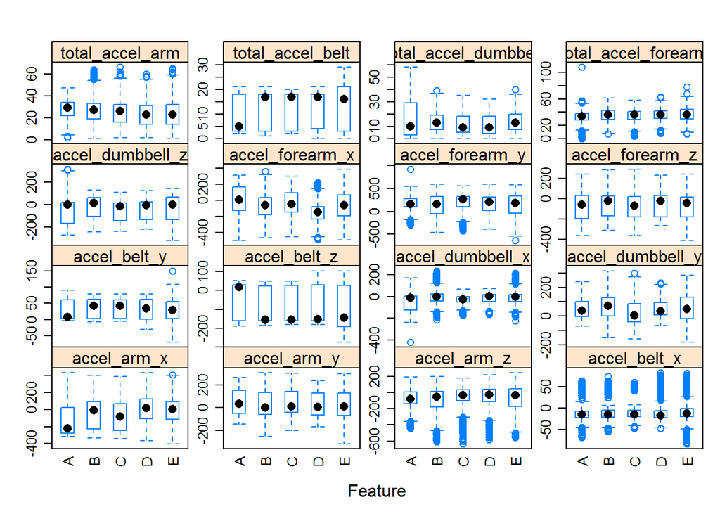

```r
featurePlot(x = TrainingData.filtered.training[, 1:16],
            y = TrainingData.filtered.training$classe,
            plot = "box",
            ## Pass in options to bwplot()
            scales = list(y = list(relation="free"),
                          x = list(rot = 90)),
            layout = c(4,4 ),
            auto.key = list(columns = 5))
```

The plot shows that total_accel_arm, total_accel_forearm, accel_dumbell_x, accel_arm_z and accel_belt_x has quite a number of outliers within the range of data available, this could mean that these varibales are of least interest to hte model. The remainder of the accelerometer data does show differences between the at least one and the rest of the classifications.

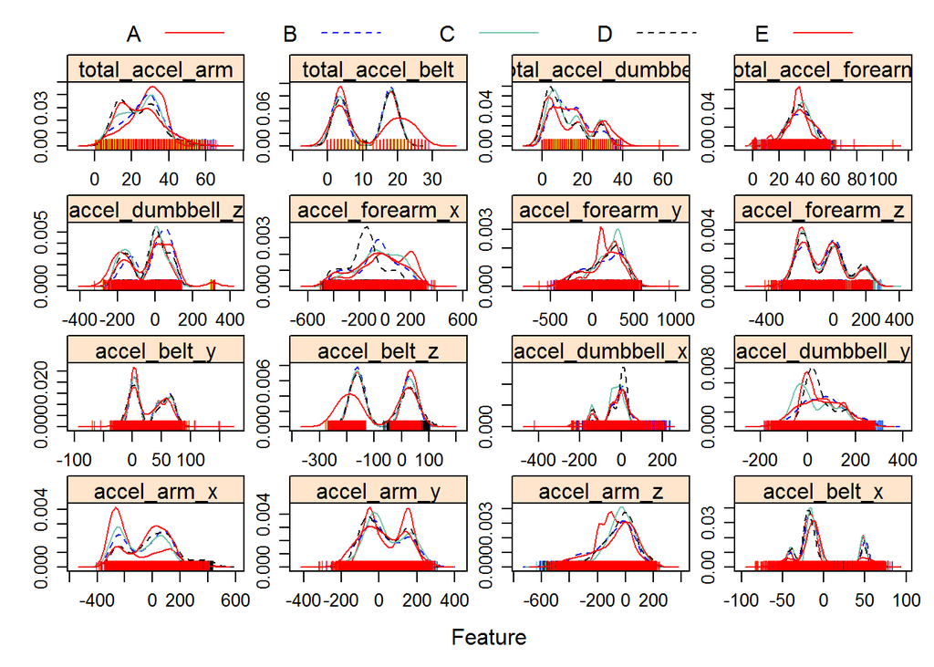

```r
transparentTheme(trans = .9)
featurePlot(x = TrainingData.filtered.training[, 1:16],
            y = TrainingData.filtered.training$classe,
            plot = "density",
            scales = list(x = list(relation="free"),
                          y = list(relation="free")),
            adjust = 1.5,
            pch = "|",
            layout = c(4,4),
            auto.key = list(columns = 5))
```

A cursory inspection of the overlayed density plots show a few interesting that may be useful for classfiction with there peaks for all the various classifications. Annoyingly the denisty plot has shown both A and E as the same colour.

## Model Training

The R package “caret” has many machine learning algorithms available for prediction, a full list can be found at http://topepo.github.io/caret/modelList.html. In this particular scenario the selected model must be a model which predicts a discrete value that can then be used to classify a subjects behaviour.

One of the problems with training machine learning algorithms on a Windows platform in R is that they can take a long time to run. The for each package allows R to execute processes sequentially or in parallel using various packages depending on the operating system the host environment is running. On a windows platform natively R does not make full use of modern multi core architecture and runs models on a single core of a processor and since the host environment this paper was executed on is a windows machine the author has chosen to address this problem. Revolution Analytics’s (recently acquired by Microsoft) have addressed the problem discussed in the paragraph above with the doParallel package, details of the package can be found at https://cran.r-project.org/web/packages/doParallel/index.html. Please note that additional binaries were downloaded from https://mran.revolutionanalytics.com/download/ in order to make this package functional. The approach for a mac or Unix machine would be different, however in all situations the caret package can make use of the parallelism to speed up model training.

```r
#Cross vailidation
fitControl <- trainControl(## 10-fold CV
        method = "repeatedcv",
        number = 10,
        ## repeated ten times
        repeats = 10)


require(doParallel);
#Detect number of cores on host enviroment less one so it remains responsive
cores <- detectCores() - 1
#Go and setup the Parrell Processing
cl <- makeCluster(cores)
registerDoParallel(cl)
#Train the models
set.seed(825)
#General Linear Model
model.regression <- train(classe ~ ., data=TrainingData.filtered.training,
                          model="glm",

                          trControl = fitControl)
set.seed(47)
#Random Forrest
model.forest <- train(classe ~ . ,
                        data=TrainingData.filtered.training,
                        model="rf",
                        trControl = fitControl)
set.seed(962)
#Recursive Partitioning and Regression Trees
model.rotate <- train(classe ~ .,
                        data=TrainingData.filtered.training,
                        model="rpart",
                        trControl = fitControl)
#Stop the cluster
stopCluster(cl)
```

To evaluate the performance of the model we must test it with the test data partition created earlier in the paper, this will use the trained models to predict a classification and we can then check this prediction against a known classification to see if the prediction was correct. The following code predicts classifications using the models trained above:

```r
#Now we have a model predict some values
predict.regression <- predict(model.regression, TrainingData.filtered.testing)
predict.forest <- predict(model.forest, TrainingData.filtered.testing)
predict.rotate <- predict(model.rotate, TrainingData.filtered.testing)
```

## Model Evaluation

In this section we will look at the performance of each of the models in turn and decide which model performs best. The models will be evaluated with a confusion matrix.

### General Linear Model

The confusion matrix for the general linear model is as follows

```r
#Produce confusion matrix for GLM
confusionMatrix(predict.regression, TrainingData.filtered.testing$classe)
```

```
## Confusion Matrix and Statistics
##
##           Reference
## Prediction    A    B    C    D    E
##          A 1617   48   12   17    2
##          B   11 1035   30    5   11
##          C   25   41  965   40    7
##          D   20    8   14  897   10
##          E    1    7    5    5 1052
##
## Overall Statistics
##
##                Accuracy : 0.9458
##                  95% CI : (0.9397, 0.9514)
##     No Information Rate : 0.2845
##     P-Value [Acc > NIR] : < 2.2e-16
##
##                   Kappa : 0.9314
##  Mcnemar's Test P-Value : 1.346e-06
##
## Statistics by Class:
##
##                      Class: A Class: B Class: C Class: D Class: E
## Sensitivity            0.9659   0.9087   0.9405   0.9305   0.9723
## Specificity            0.9812   0.9880   0.9767   0.9894   0.9963
## Pos Pred Value         0.9534   0.9478   0.8952   0.9452   0.9832
## Neg Pred Value         0.9864   0.9783   0.9873   0.9864   0.9938
## Prevalence             0.2845   0.1935   0.1743   0.1638   0.1839
## Detection Rate         0.2748   0.1759   0.1640   0.1524   0.1788
## Detection Prevalence   0.2882   0.1856   0.1832   0.1613   0.1818
## Balanced Accuracy      0.9736   0.9483   0.9586   0.9600   0.9843
```

### Random Forrest

The confusion Matrix for the Random Forest is as follows

```r
#Produce confusion matrix for GLM
confusionMatrix(predict.forest, TrainingData.filtered.testing$classe)
```

```
## Confusion Matrix and Statistics
##
##           Reference
## Prediction    A    B    C    D    E
##          A 1618   50   15   15    3
##          B   11 1034   27    8    9
##          C   23   39  966   38    6
##          D   21    8   14  899    8
##          E    1    8    4    4 1056
##
## Overall Statistics
##
##                Accuracy : 0.947
##                  95% CI : (0.9409, 0.9526)
##     No Information Rate : 0.2845
##     P-Value [Acc > NIR] : < 2.2e-16
##
##                   Kappa : 0.9329
##  Mcnemar's Test P-Value : 3.773e-06
##
## Statistics by Class:
##
##                      Class: A Class: B Class: C Class: D Class: E
## Sensitivity            0.9665   0.9078   0.9415   0.9326   0.9760
## Specificity            0.9803   0.9884   0.9782   0.9896   0.9965
## Pos Pred Value         0.9512   0.9495   0.9011   0.9463   0.9842
## Neg Pred Value         0.9866   0.9781   0.9875   0.9868   0.9946
## Prevalence             0.2845   0.1935   0.1743   0.1638   0.1839
## Detection Rate         0.2749   0.1757   0.1641   0.1528   0.1794
## Detection Prevalence   0.2890   0.1850   0.1822   0.1614   0.1823
## Balanced Accuracy      0.9734   0.9481   0.9599   0.9611   0.9862
```

### Recursive Partitioning and Regression Trees

The confusion Matrix for the Recursive Partitioning and Regression Trees algorithm is as follows

```r
#Produce confusion matrix for rpart
confusionMatrix(predict.rotate, TrainingData.filtered.testing$classe)
```

```
## Confusion Matrix and Statistics
##
##           Reference
## Prediction    A    B    C    D    E
##          A 1622   50   15   14    1
##          B   10 1038   28    7   10
##          C   22   37  967   34    8
##          D   19    8   11  905    8
##          E    1    6    5    4 1055
##
## Overall Statistics
##
##                Accuracy : 0.9494
##                  95% CI : (0.9434, 0.9548)
##     No Information Rate : 0.2845
##     P-Value [Acc > NIR] : < 2.2e-16
##
##                   Kappa : 0.9359
##  Mcnemar's Test P-Value : 2.322e-06
##
## Statistics by Class:
##
##                      Class: A Class: B Class: C Class: D Class: E
## Sensitivity            0.9689   0.9113   0.9425   0.9388   0.9750
## Specificity            0.9810   0.9884   0.9792   0.9907   0.9967
## Pos Pred Value         0.9530   0.9497   0.9054   0.9516   0.9851
## Neg Pred Value         0.9876   0.9789   0.9878   0.9880   0.9944
## Prevalence             0.2845   0.1935   0.1743   0.1638   0.1839
## Detection Rate         0.2756   0.1764   0.1643   0.1538   0.1793
## Detection Prevalence   0.2892   0.1857   0.1815   0.1616   0.1820
## Balanced Accuracy      0.9750   0.9499   0.9609   0.9647   0.9859
```

### Summary

For the Recursive Partitioning and Regression Trees model the important of the input variables is as follows

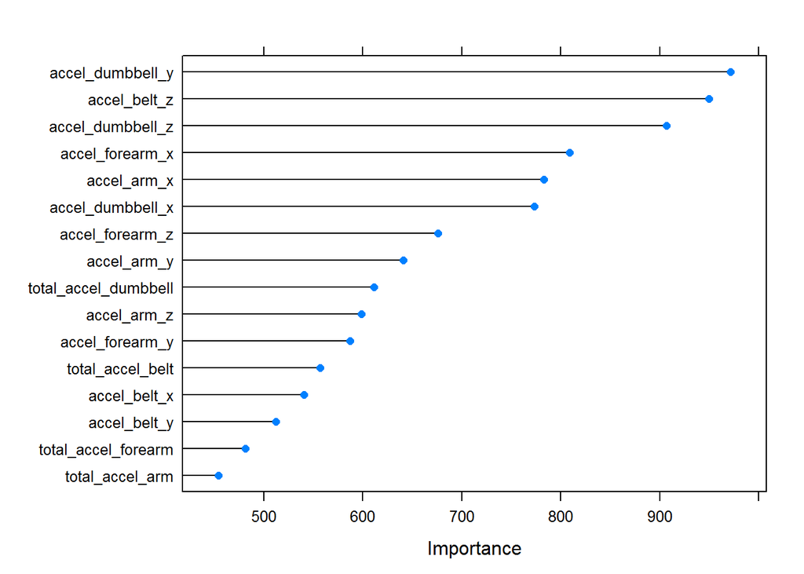

```r
treeImp <- varImp(model.rotate, scale=FALSE)
plot(treeImp, top = 16)
```

It is interesteing to note that the variables total_accel_arm, total_accel_forearm, accel_belt_x, accel_arm_z are all fairly low down on the chart above with regards to important and all of these variables had a significant number of outliers on the boxplot chart.

## Prediction

The final part of the assignment is to predict values for the test data set provided. The following r code uses the Recursive Partitioning and Regression Trees to predict the classification of the exercise for the test data provided

```r
predict.tree.test <- predict(model.rotate, TestData.filtered)
```

When this was submitted to coursera for marking an score of 95% was returned which is in line with the model accuracy reporting by the confusion matrix.

(1672 Words)